# Car Noise Data Analysis

jeeyeonLIM

- 임시 주제 : 실내 소음을 바탕으로 자동차 군집화 및 소음 원인 탐색

# 1. Data Setting, Handling

```r
library(ggplot2)
library(tidyverse)
library(reshape2)
library(ggthemes)
options(scipen=100)

### 1. Kaggle 데이터
car_noise= read.csv('car_noise_specification_datasets.csv',
             sep = "\t",
             stringsAsFactors = F,
             na.strings = c("", "NA"))

### 2. 변수 제거
car_noise_complete = car_noise %>% filter( model_id != "NaN") %>%
    select(

    # 결측치 심각
        -model_co2_cqa, -ExtColors_cqa  ,-IntColors_cqa,

    # 결측치 60%이상
        # -model_engine_bore_mm_cqa,
        # -model_engine_bore_in_cqa,
        # -model_engine_stroke_mm_cqa,
        # -model_engine_stroke_in_cqa,
        #
        # -model_0_to_100_kph_cqa,
        #
        # -model_top_speed_kph_cqa,
        # -model_top_speed_mph_cqa,

    # 중복값
        -model_id,
        -model_id_cqa,
        -make_display_cqa,
        -model_make_display_cqa,
        -model_make_id_cqa,
        -model_name_cqa,
        -model_year_cqa,

    # 단위 중복칼럼 제거
      -model_weight_lbs_cqa,
      -model_height_in_cqa,
      -model_wheelbase_in_cqa,

      -model_width_in_cqa,
      -model_length_in_cqa,

      -model_mpg_city_cqa,
      -model_mpg_hwy_cqa,
      -model_mpg_mixed_cqa,
      -model_fuel_cap_g_cqa,

      -model_engine_ci_cqa,
      -model_engine_l_cqa,

      -model_engine_power_hp_cqa,
      -model_engine_power_ps_cqa,
      -model_engine_power_rpm_cqa,

      -model_engine_torque_lbft_cqa,
      -model_engine_torque_nm_cqa,
      -model_engine_torque_rpm_cqa
    )
### 3. 전처리
car_noise_complete =car_noise_complete  %>%
  mutate(model_engine_type_cqa = ifelse(model_engine_type_cqa=="Inline","in-line",model_engine_type_cqa ),
         model_drive_cqa = ifelse(model_drive_cqa %in% c("AWD ","AWD"), "Four Wheel Drive",
                                  ifelse(model_drive_cqa %in% c("front","Front"), "Front Wheel Driv",
                                         ifelse(model_drive_cqa== "4WD" , "All Wheel Drive",
                                                ifelse(model_drive_cqa=="Rear","Rear Wheel Drive",model_drive_cqa)))))
```

# 2. Clustering

- 방법 : dB_at_idle,dB_at_50kmh,dB_at_80kmh,dB_at_100kmh,dB_at_120kmh,dB_at_140kmh 변수 바탕으로 통계량(표본평균, 표준편차, 최대값, 변동계수) 산출하고 2변량 Clustering
- 결과 : 기준변수는 대표값, 편차를 선정해서 2변수 기준으로 Clustering함.
- 이유 : mean, sd 기준으로 했을때와 비슷한 결과 나오지만 보다 극단적인 값(max)을 기준으로 Noise 큰 그룹, 작은그룹으로 나누고자 max, CV 사용. CV를 활용한 이유는 sd보다 차마다 다른 dB단위를 보완해주고자 함.

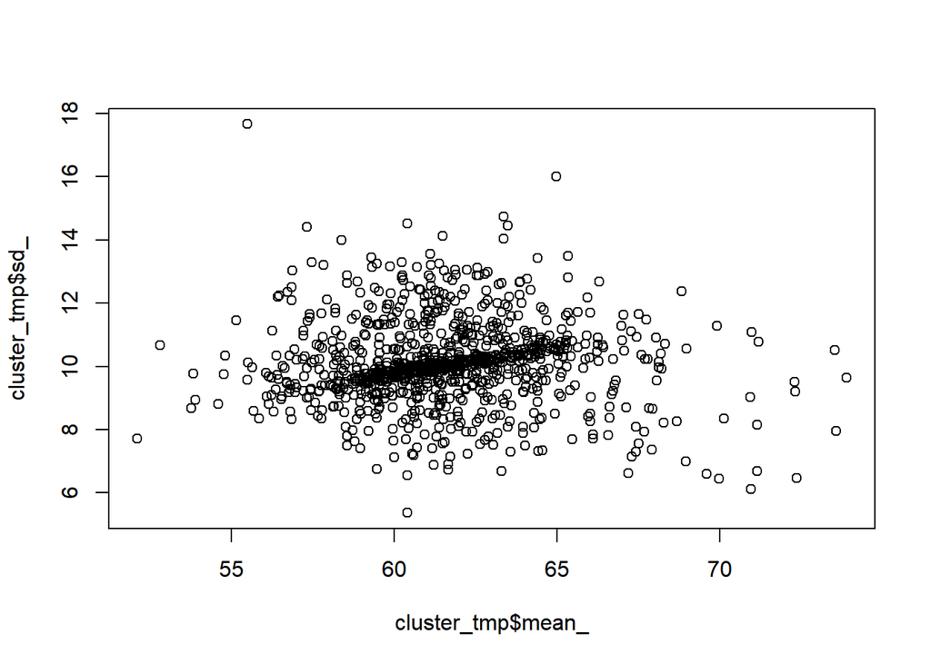

```r
cluster_tmp=
  car_noise_complete %>%
  select(X,dB_at_idle,dB_at_50kmh,dB_at_80kmh,dB_at_100kmh,dB_at_120kmh,dB_at_140kmh) %>%
  melt("X") %>%
  group_by(X) %>%
  summarise(mean_ = mean(value), sd_= sd(value), max_= max(value), cv_=sd(value)/mean(value))


plot(cluster_tmp$mean_,cluster_tmp$sd_)
```

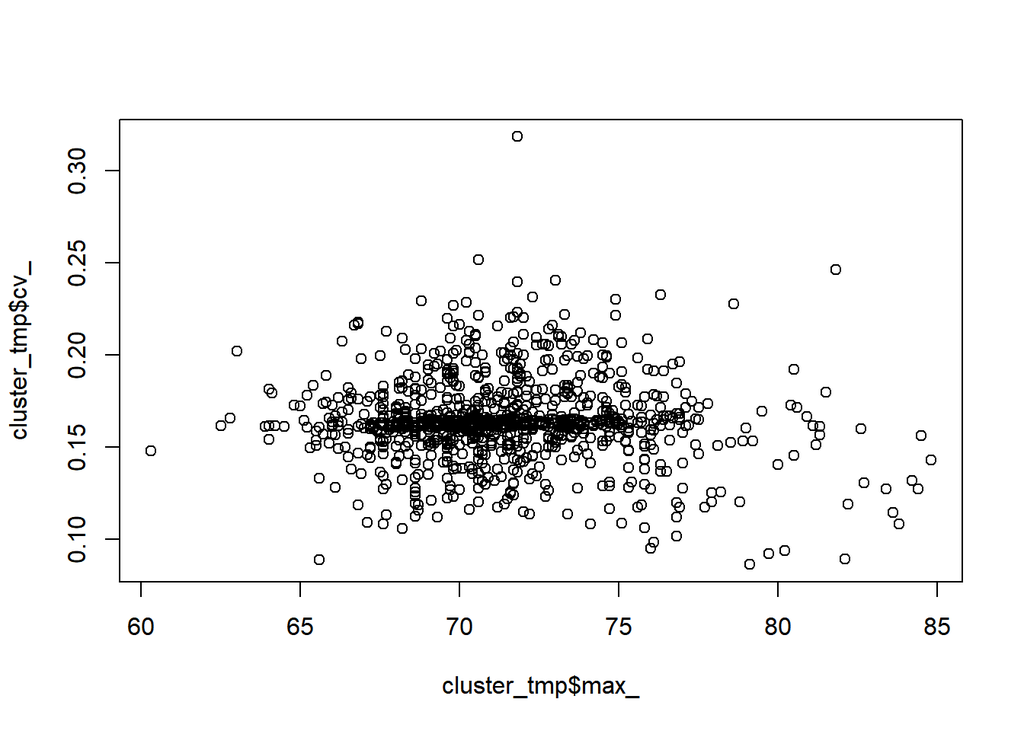

```r
plot(cluster_tmp$max_,cluster_tmp$cv_) # max, cv 로 기준변수 선정
```

## Scaling

- Clustering 전 표준화.

```r
#seg_scale = scale(cluster_tmp %>% select(mean_,sd_ ))
seg_scale = scale(cluster_tmp %>% select(max_,cv_ ))
```

## Cluster 수 결정

- 몇개의 Cluster가 적절한 것인지 NbClust를 통한 확인 및 elbow 차트 확인.
- 결과 : 3개 클러스터로 나누어 살펴보기로 함.

```r
  library(NbClust)
```

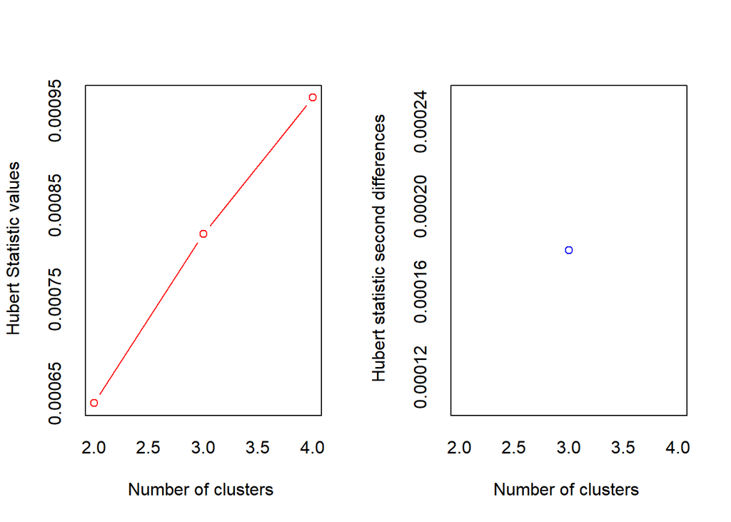

```
## *** : The Hubert index is a graphical method of determining the number of clusters.
##                 In the plot of Hubert index, we seek a significant knee that corresponds to a
##                 significant increase of the value of the measure i.e the significant peak in Hubert
##                 index second differences plot.
##
```

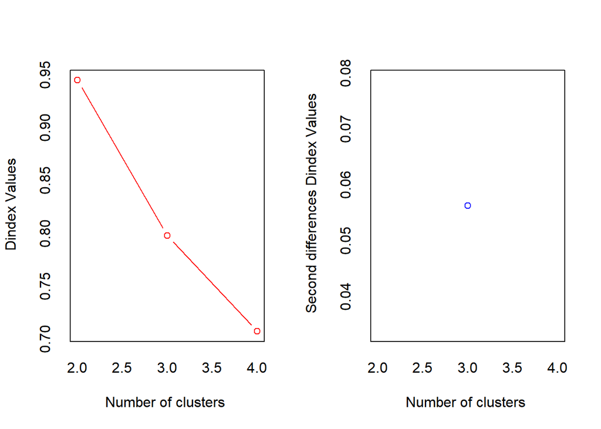

```
## *** : The D index is a graphical method of determining the number of clusters.
##                 In the plot of D index, we seek a significant knee (the significant peak in Dindex
##                 second differences plot) that corresponds to a significant increase of the value of
##                 the measure.
##
## * Among all indices:
## * 7 proposed 2 as the best number of clusters
## * 11 proposed 3 as the best number of clusters
## * 5 proposed 4 as the best number of clusters
##
##                    ***** Conclusion *****
##
## * According to the majority rule, the best number of clusters is  3
##
##
```

```r
  nc <- NbClust(seg_scale , min.nc=2, max.nc=4, method="kmeans")
```

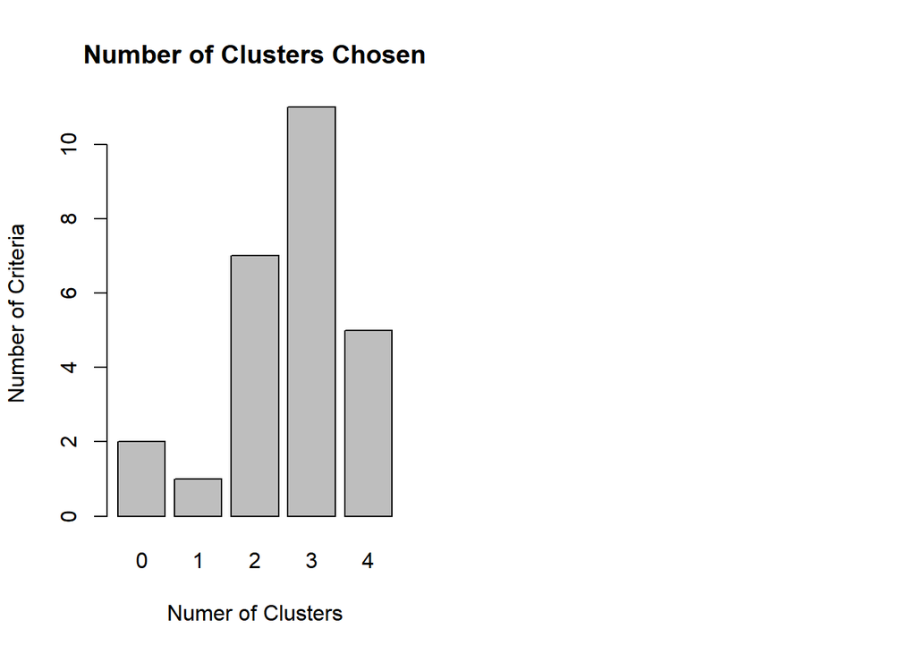

```r
  barplot(table(nc$Best.n[1,]),
   xlab="Numer of Clusters", ylab="Number of Criteria",
   main="Number of Clusters Chosen")
```

## 본격적인 Clusterin(K-means)

- kmeans 패키지 활용한 Clustering
- kmeans 방법은 다른 클러스터링 방법보다 극단값에 민감한 특성을 갖는데, 본 분석의 목적인 그룹간 차이를 살펴보는 것이기 때문에 해당 방법을 사용함.

```r
num_of_clust = 3
set.seed(7)
time.clustering = kmeans(seg_scale, num_of_clust,iter.max=100000 )

table(time.clustering$cluster)
```

```
##
##   1   2   3
## 616 186 265
```

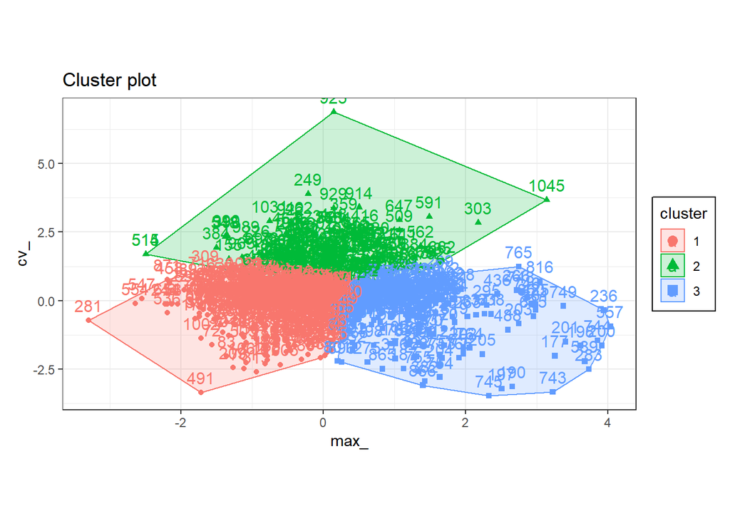

```r
cluster_tmp$cluster = as.factor(time.clustering$cluster)


### Clustering 기준변수에 따른 결과
# ggplot(cluster_tmp) + geom_point(aes(x=mean_,y=sd_, color=cluster))
# ggplot(cluster_tmp) + geom_point(aes(x=max_,y=cv_, color=cluster)) +theme_bw()

library(factoextra)
fviz_cluster(time.clustering, seg_scale)+ theme_bw()+theme(
    legend.background = element_rect(color = 'black',
                                            size = 0.5),plot.margin=margin(50,10,50,10))
```

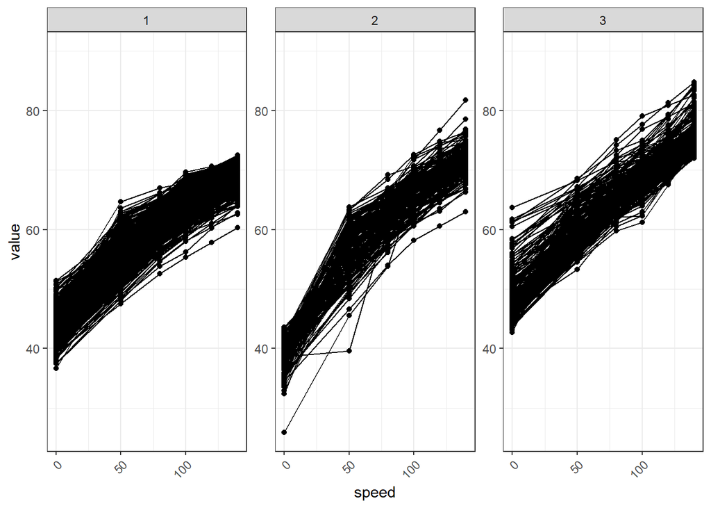

```r
result_graph=
car_noise_complete %>%
    select(contains("dB_at"), X) %>%
    melt(id="X") %>%
    mutate(speed=ifelse(variable == "dB_at_idle",0,
                        ifelse(variable == "dB_at_50kmh",50,
                               ifelse(variable == "dB_at_80kmh",80,
                                      ifelse(variable == "dB_at_100kmh",100,
                                             ifelse(variable == "dB_at_120kmh",120,140)))))) %>%
  select(X,speed,value) %>%
  left_join(cluster_tmp %>% select(X, cluster), by=c("X"="X"))
### Clustering 결과 속도에 따른 소음 형태
ggplot( result_graph, aes(x=speed,y=value,group=X)) +
  facet_wrap(~cluster, scales="free") +coord_cartesian(ylim = c(25.9,90))+
  geom_point() + geom_line() +theme_bw() + theme(axis.text.x = element_text(angle = 45, hjust = 1))
```

- 그룹1 : 전반적으로 정숙한 그룹 (최대값이 73 이하)
- 그룹2 : 중간정도의 소음을 갖지만 속도에 따라 편차가 큰 그룹(최대값이 전체적으로 중간 값 갖지만 CV값이 다소 큼)
- 그룹3 : 전반적으로 소음이 큰 그룹(최대값이 73 이상) #### Cluster1,2,3!!
- 따라서 Cluster1 ~3의 의미가 명확하다고 판단했으며 각각의 그룹별로 어떤 특성이 다른지를 살펴보고 의미를 탐색해보고자 함.
- Ex) Cluster1은 다른 그룹에 비해서 어떠한 특징이 있길래 소음이 낮을까, Cluster2는 최대값에 관계없이 속도에 따라서 Noise 편차가 매우 큰 그룹인데 원인이 무엇일까? , Cluster3는 소음이 전반적으로 매우 큰 집단인데 어떤 특성을 갖고 있으며 어떤 상황에서 심각한 문제가 생길 수 있을까?

# 3. Explore Cluster 1,2,3

- 생성된 클러스터별 특성 구체적으로 탐색하기
- deep_cluster : 기존 데이터셋에 클러스터 부여한 데이터셋

```r
library(RColorBrewer)
```

```r
deep_cluster=
    car_noise_complete %>% left_join(
    result_graph %>% select(X, cluster) %>% unique(), by = c("X"="X")
    )
```

## Visualization

- 우선 클러스터별 어떤 특징이 있는지 전체 변수 시각화해보고 의미찾아보기

### 1. Categorical variables

```r
### 변수 확인
deep_cluster %>% select_if(is.character) %>% colnames()
```

```
##  [1] "brand"                        "model"
##  [3] "spec"                         "model_trim_cqa"
##  [5] "model_body_cqa"               "model_engine_position_cqa"
##  [7] "model_engine_type_cqa"        "model_engine_compression_cqa"
##  [9] "model_engine_fuel_cqa"        "model_drive_cqa"
## [11] "model_transmission_type_cqa"  "make_country_cqa"
```

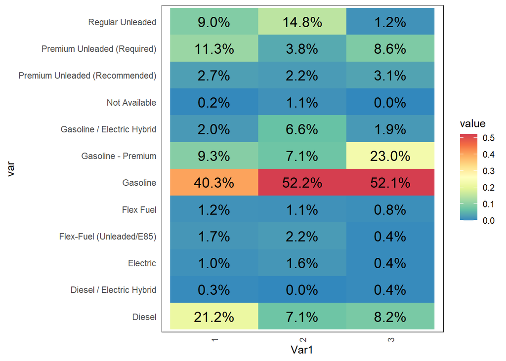

```r
 # [1] "brand"                        "model"                        "spec"                         "model_trim_cqa"
 # [5] "model_body_cqa"               "model_engine_position_cqa"    "model_engine_type_cqa"  "model_engine_compression_cqa"
 # [9] "model_engine_fuel_cqa"        "model_drive_cqa"              "model_transmission_type_cqa"  "make_country_cqa"

### Categorical Visualization Function
categorical_grp = function(data, var){
  aa=data.frame( table(data$cluster, var))
  sum_table=aa %>% group_by(Var1) %>% summarise(sum=sum(Freq))
  grp= aa %>% left_join(sum_table, by=c("Var1"="Var1")) %>%
    mutate(percent= Freq/sum) %>%
    ggplot(aes(x = Var1, y = var, fill = percent, label = sprintf("%1.1f%%", 100*percent) ))+
      geom_tile()+ theme_bw() +
    theme(plot.background = element_blank(),
                     panel.grid.minor = element_blank(),
                     panel.grid.major = element_blank(),
                     panel.background = element_blank(),
                     axis.line = element_blank(),
                     axis.ticks = element_blank(),
                     strip.background = element_rect(fill = "white", colour = "white"),
                     axis.text.x = element_text(angle = 90, vjust = 0.5, hjust = 1))+
    geom_text(size=5,colour = "black") +
    scale_fill_gradientn("value", colours = rev(brewer.pal(9, "Spectral")), na.value = "white")
  #labs(title = my_title, x = NULL, fill = my_title)
  print(grp)
}

categorical_grp(deep_cluster,deep_cluster$model_engine_fuel_cqa) # 가솔린 가장많고 1그룹디젤, 3그룹 가솔린프리미엄
```

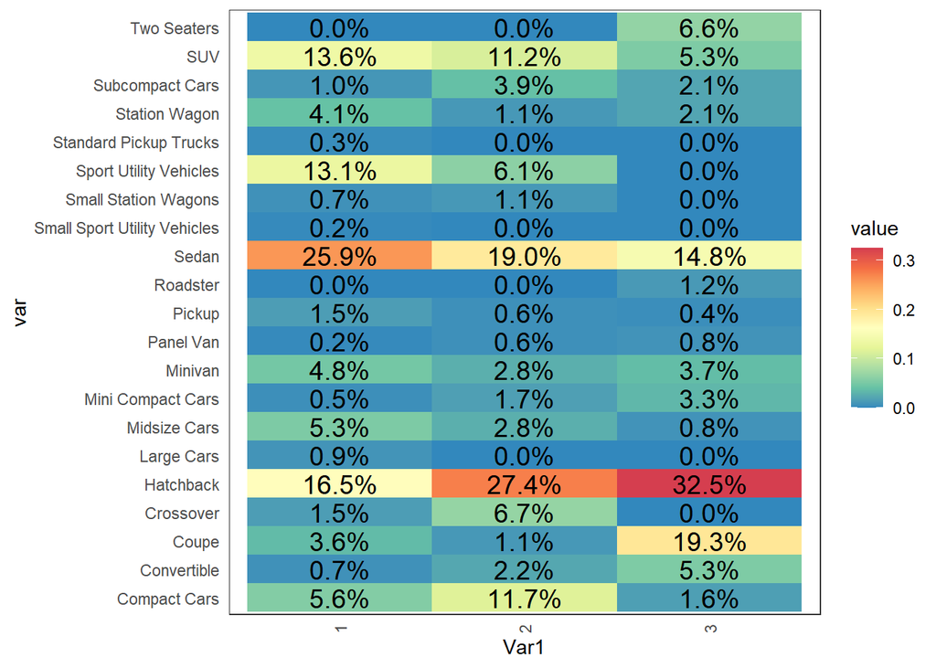

```r
categorical_grp(deep_cluster,deep_cluster$model_body_cqa) # 3그룹 주로 해치백
```

[figure not shown]

```r
categorical_grp(deep_cluster,deep_cluster$brand) # 1그룹 아우디, 아우디가 조용한 편인가?
```

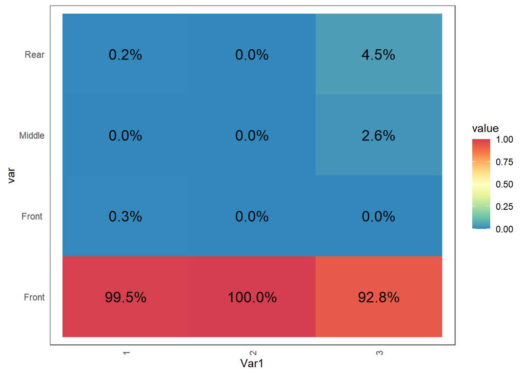

```r
categorical_grp(deep_cluster,deep_cluster$model_engine_position_cqa) # 3그룹 엔진위치 중간과 뒤쪽도 고루분포
```

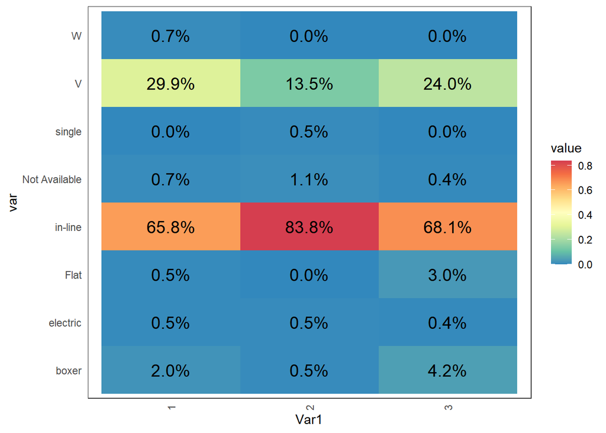

```r
categorical_grp(deep_cluster,deep_cluster$model_engine_type_cqa) # 그룹공통으로 inline, v 형태가 가장 많음
```

[figure not shown]

```r
categorical_grp(deep_cluster,deep_cluster$model_engine_compression_cqa) # 그룹3의 압축비가 10.5.1이 많았다. 나머지 두 그룹은 9.6이 많았다
```

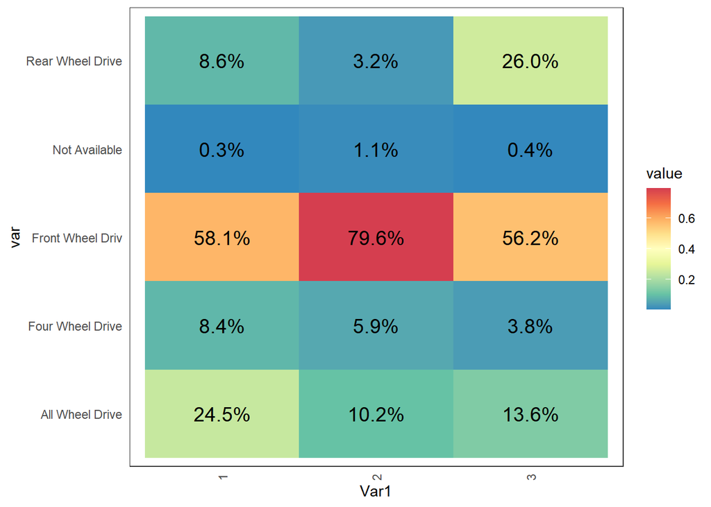

```r
categorical_grp(deep_cluster,deep_cluster$model_drive_cqa) # 그룹공통으로 Front Wheel Drive, 그룹1은 AWD, 그룹3은 Real Wheel Drive
```

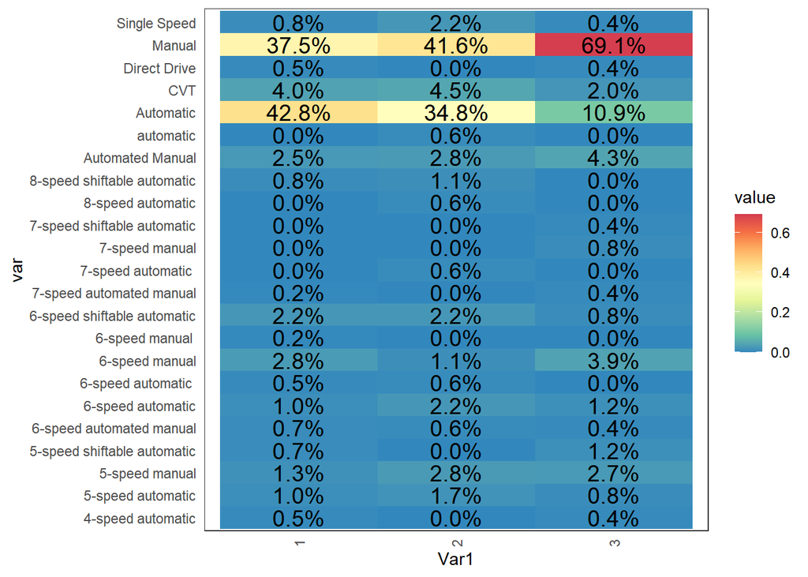

```r
categorical_grp(deep_cluster,deep_cluster$model_transmission_type_cqa) ################### 전처리 필요 ..
```

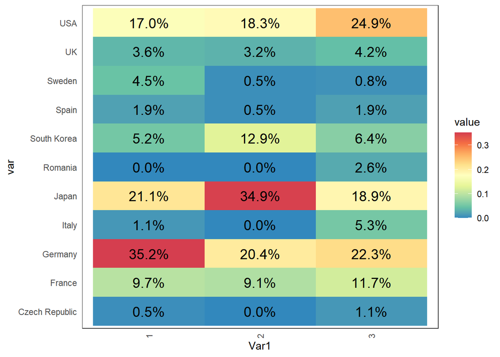

```r
categorical_grp(deep_cluster,deep_cluster$make_country_cqa)# ****** 그룹1은 주로 독일차, 독일차조용한가? 그룹2는 일본, 그룹3은 미국차
```

### 2. Numeric variables

```r
deep_cluster %>% select_if(is.numeric) %>% colnames()
```

```
##  [1] "X"                               "year"
##  [3] "dB_at_idle"                      "dB_at_50kmh"
##  [5] "dB_at_80kmh"                     "dB_at_100kmh"
##  [7] "dB_at_120kmh"                    "dB_at_140kmh"
##  [9] "model_engine_cc_cqa"             "model_engine_cyl_cqa"
## [11] "model_engine_valves_per_cyl_cqa" "model_engine_bore_mm_cqa"
## [13] "model_engine_stroke_mm_cqa"      "model_top_speed_kph_cqa"
## [15] "model_0_to_100_kph_cqa"          "model_seats_cqa"
## [17] "model_doors_cqa"                 "model_weight_kg_cqa"
## [19] "model_length_mm_cqa"             "model_width_mm_cqa"
## [21] "model_height_mm_cqa"             "model_wheelbase_mm_cqa"
## [23] "model_lkm_hwy_cqa"               "model_lkm_mixed_cqa"
## [25] "model_lkm_city_cqa"              "model_fuel_cap_l_cqa"
## [27] "model_sold_in_us_cqa"            "model_engine_bore_in_cqa"
## [29] "model_engine_stroke_in_cqa"      "model_engine_valves_cqa"
## [31] "model_engine_power_kw_cqa"       "model_engine_torque_kgm_cqa"
## [33] "model_top_speed_mph_cqa"
```

```r
# [1] "X"                               "year"
#  [4] "dB_at_idle" "dB_at_50kmh" "dB_at_80kmh""dB_at_100kmh""dB_at_120kmh""dB_at_140kmh"

# "model_engine_cc_cqa"
# [10] "model_engine_cyl_cqa"            "model_engine_valves_per_cyl_cqa" "model_engine_bore_mm_cqa"
# [13] "model_engine_stroke_mm_cqa"      "model_top_speed_kph_cqa"         "model_0_to_100_kph_cqa"
# [16] "model_seats_cqa"                 "model_doors_cqa"                 "model_weight_kg_cqa"
# [19] "model_length_mm_cqa"             "model_width_mm_cqa"              "model_height_mm_cqa"
# [22] "model_wheelbase_mm_cqa"          "model_lkm_hwy_cqa"               "model_lkm_mixed_cqa"
# [25] "model_lkm_city_cqa"              "model_fuel_cap_l_cqa"            "model_sold_in_us_cqa"
# [28] "model_engine_bore_in_cqa"        "model_engine_stroke_in_cqa"      "model_engine_valves_cqa"
# [31] "model_engine_power_kw_cqa"       "model_engine_torque_kgm_cqa"     "model_top_speed_mph_cqa"
library(ggridges)
```

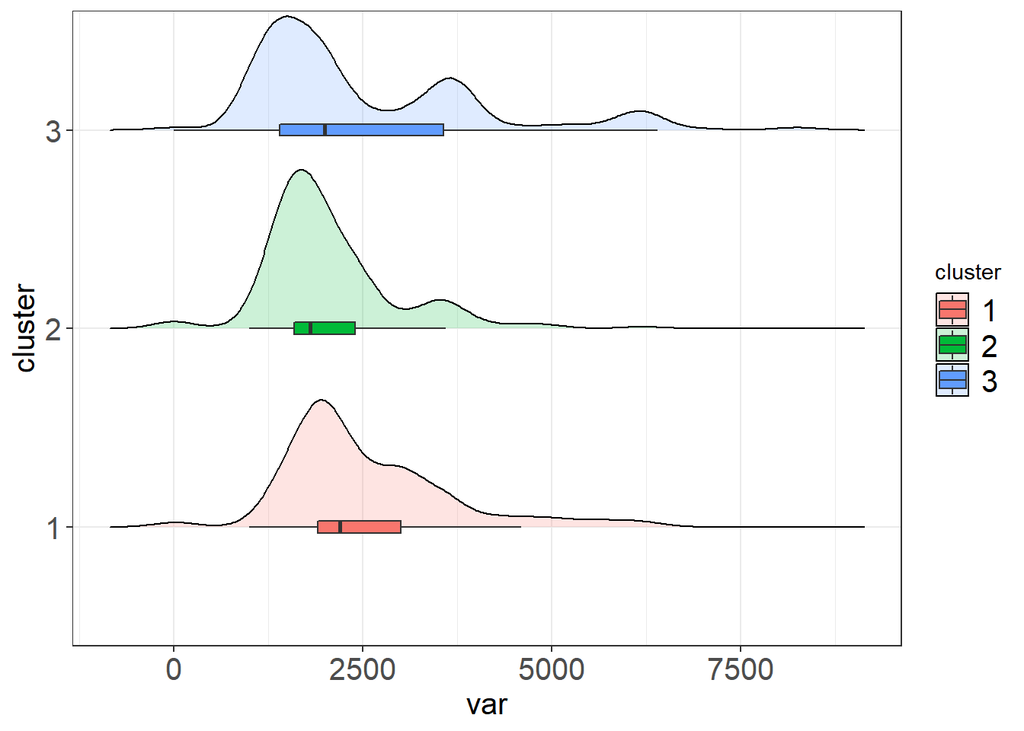

```r
numeric_grp = function(data, var){
  num=data.frame( cluster=data$cluster, var)
  num_grp=
    ggplot(num, aes(x = var, y =  cluster)) +
    geom_density_ridges(aes(fill = cluster), alpha=0.2, scale=0.8) +
    #geom_bar(stat='identity')+
    geom_boxplot(aes(fill = cluster), width = 0.06, outlier.shape = NA)+theme_bw() +
    theme(axis.text.x = element_text(size=15),
          axis.text.y = element_text(size=15),
          axis.title=element_text(size=15),
          legend.text = element_text(size = 15))
  print(num_grp)
}

numeric_grp(deep_cluster, deep_cluster$model_engine_cc_cqa)
```

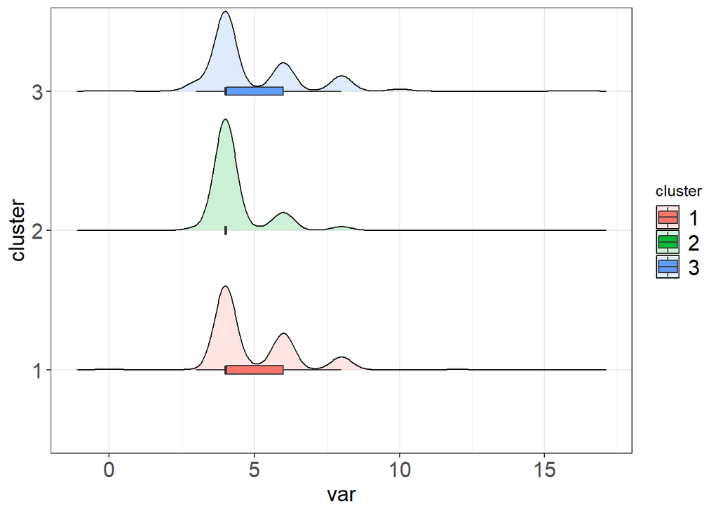

```r
numeric_grp(deep_cluster, deep_cluster$model_engine_cyl_cqa)
```

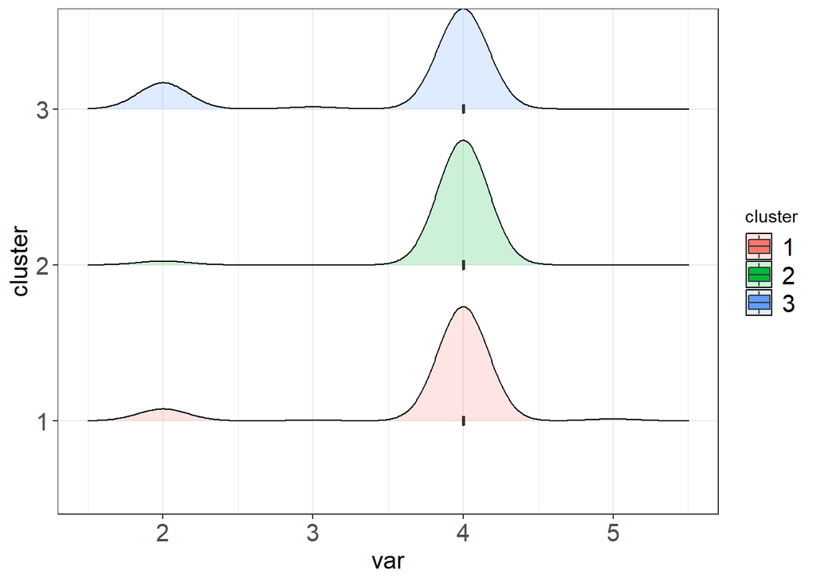

```r
numeric_grp(deep_cluster, deep_cluster$model_engine_valves_per_cyl_cqa)
```

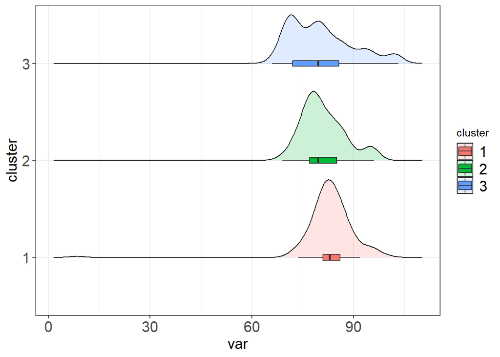

```r
numeric_grp(deep_cluster, deep_cluster$model_engine_bore_mm_cqa)
```

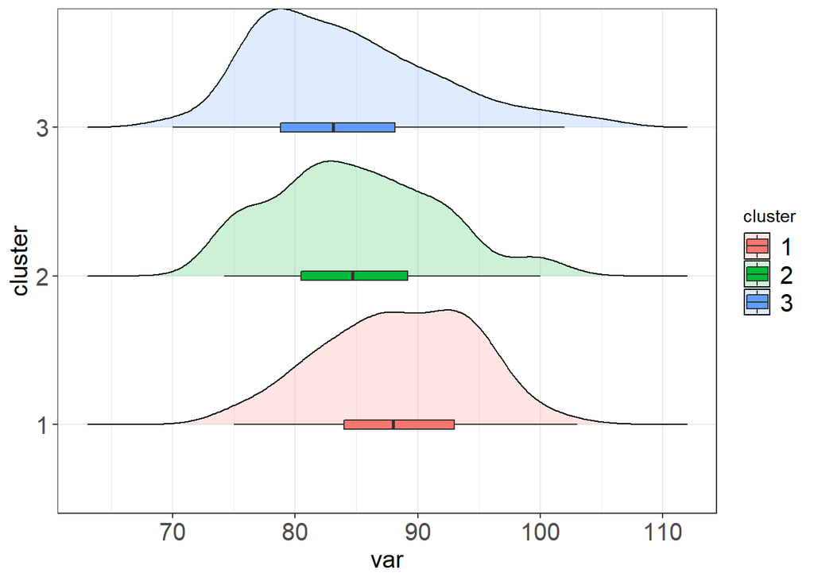

```r
numeric_grp(deep_cluster, deep_cluster$model_engine_stroke_mm_cqa)
```

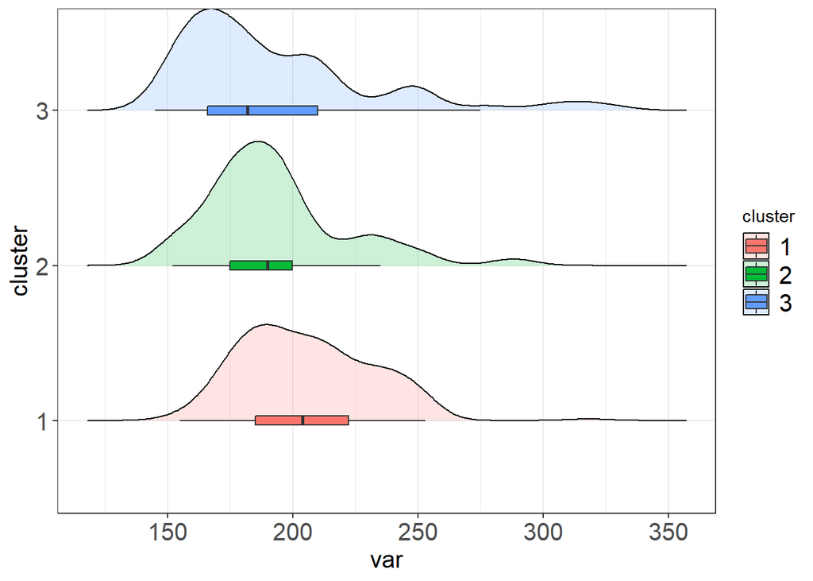

```r
numeric_grp(deep_cluster, deep_cluster$model_top_speed_kph_cqa)
```

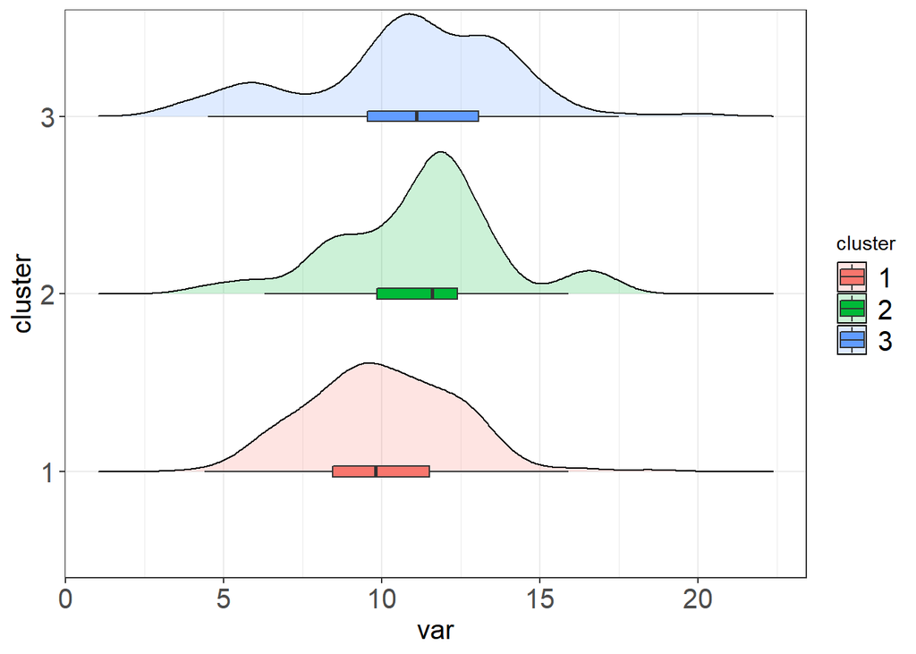

```r
numeric_grp(deep_cluster, deep_cluster$model_0_to_100_kph_cqa)
```

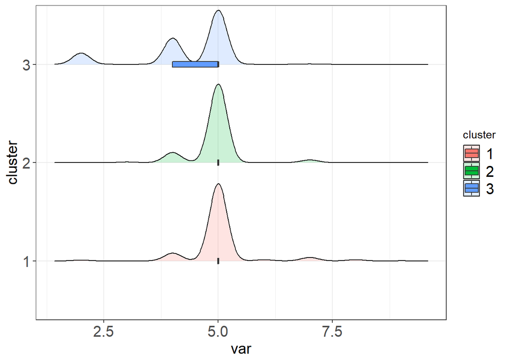

```r
numeric_grp(deep_cluster, deep_cluster$model_seats_cqa)
```

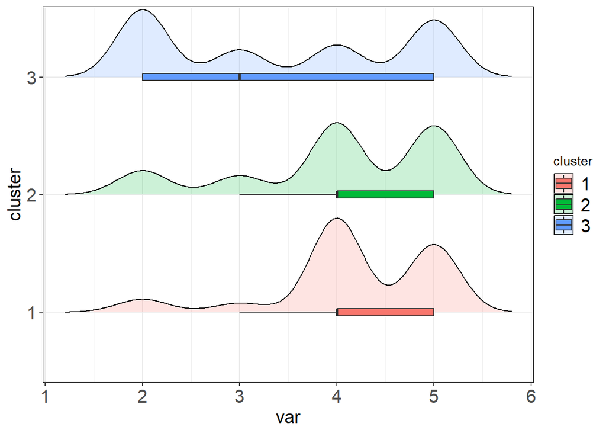

```r
numeric_grp(deep_cluster, deep_cluster$model_doors_cqa)
```

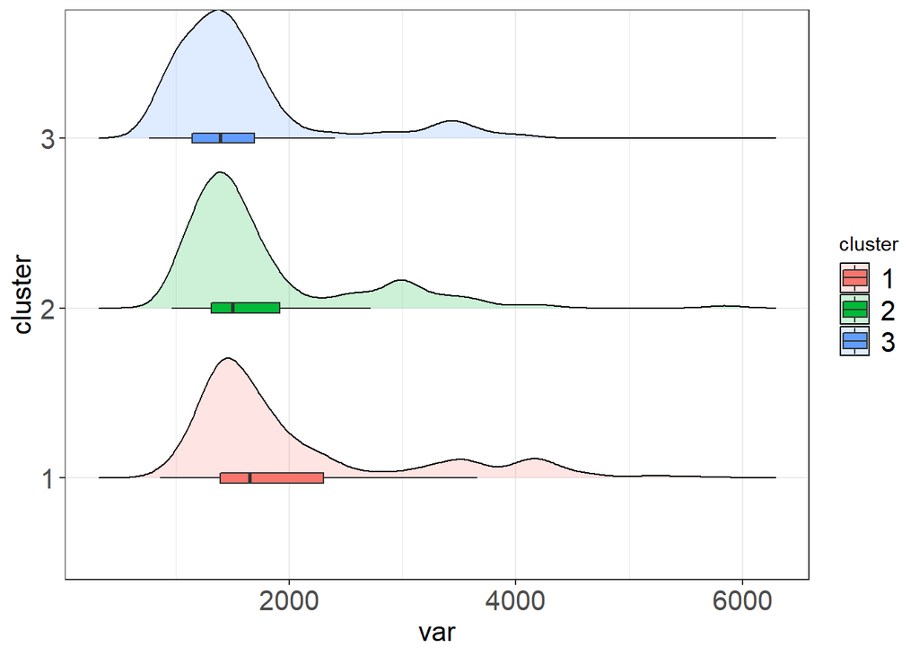

```r
numeric_grp(deep_cluster, deep_cluster$model_weight_kg_cqa)
```

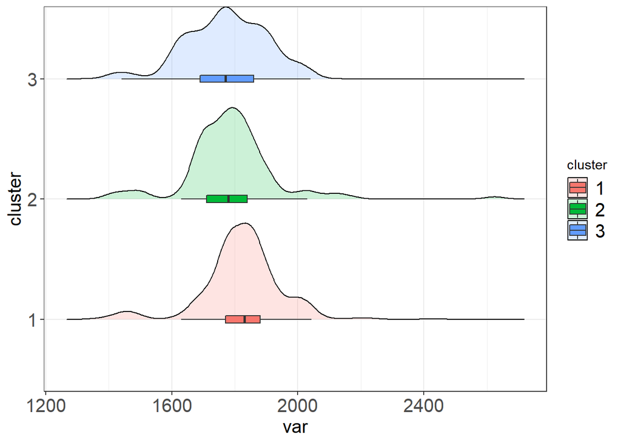

```r
numeric_grp(deep_cluster, deep_cluster$model_width_mm_cqa)
```

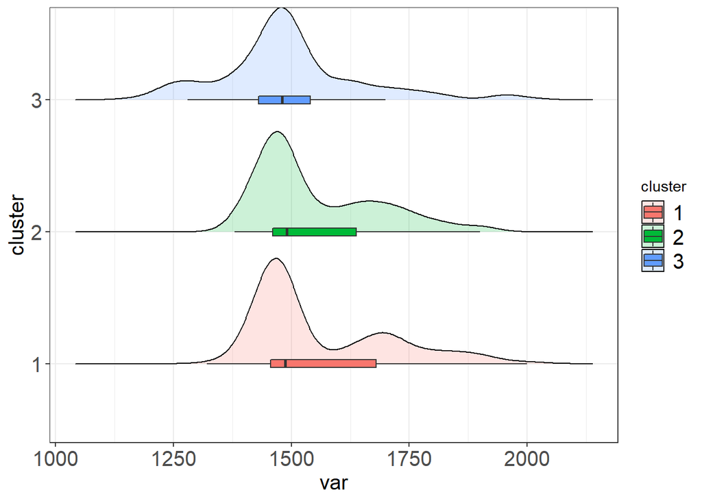

```r
numeric_grp(deep_cluster, deep_cluster$model_height_mm_cqa)
```

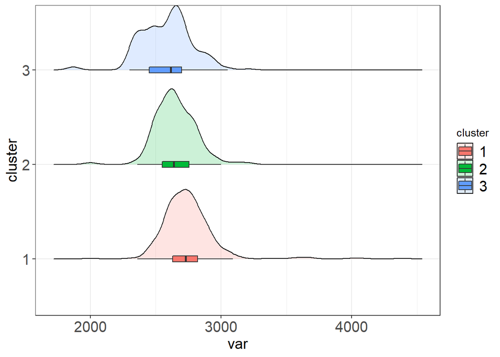

```r
numeric_grp(deep_cluster, deep_cluster$model_wheelbase_mm_cqa)
```